# Stenella spp. habitat models

```r
library(mgcv)
library(MASS)
library(rgdal)
library(raster)
library(ggplot2)
library(rgeos)
library(mapview)
library(leaflet)
library(psych)
library(broom)
library(plotrix)
library(magrittr)
library(colorRamps)
library(lubridate)
library(HabitatProject)
library(lmtest)
source('E:/NASData/AcoustoVisualDE/AcoustoVisualDE/HabitatProject/R/multiplot.R')
options(stringsAsFactors = FALSE)
# load some preferences
load('E:/NASData/ModelData/Ssp/setup_info_Ssp.Rdata')
load('E:/NASData/ModelData/Ssp/SspMergedData.Rdata')
outDir <- file.path('E:/NASData/ModelData',SP,'/')
```

# I. Exploratory analysis

## Data Inputs

The visual data goes back to 1992, but as shown in the figure below, many predictor variables are only available starting in 2003, therefore earlier visual data is currently excluded from further analyses.

Note: Future work could use monthly climatologies (averages) so that older sightings data could be used. Some dynamic drivers like eddy and front locations would not be able to be considered using that approach.

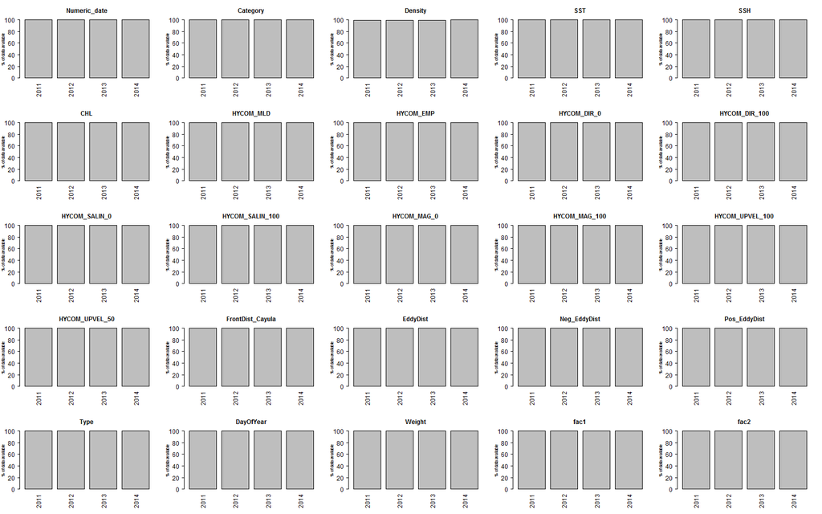

```r
covarList<-names(mergedSegments[c(2,5:length(mergedSegments))])

percFilled <- plot.missingdata(mergedSegments,covarList,paste0(outDir,'AcousticAndVisual_',SP))
percFilled <- plot.missingdata(AcOnlySegments,covarList,paste0(outDir,'AcousticOnly_',SP))
percFilled <- plot.missingdata(VisOnlySegments,covarList,paste0(outDir,'VisualOnly_',SP))
```

### Testing and Training Sets

The data are split into training and testing sets. In this case, data from 2009 and 2013 are used for testing. Only observations post-2003 are used for modeling due to covariate limitations.

```r
# If you decide from the missing data plots that you want to restrict years going forward:
yearListIdx = as.numeric(format(mergedSegments$date,"%Y"))
yearListIdx_AcOnly = as.numeric(format(AcOnlySegments$date,"%Y"))
yearListIdx_VisOnly = as.numeric(format(VisOnlySegments$date,"%Y"))

keepDates.train <- which(yearListIdx != 2009 & yearListIdx >= 2003 & yearListIdx <= 2012)
keepDates.test <- which(yearListIdx == 2009 | yearListIdx == 2013)
keepDates_AcOnly.train <- which(yearListIdx_AcOnly != 2009 & yearListIdx_AcOnly >= 2003 & yearListIdx_AcOnly <= 2012)
keepDates_AcOnly.test <- which(yearListIdx_AcOnly == 2009 | yearListIdx_AcOnly == 2013)
keepDatesVisOnly.train <- which(yearListIdx_VisOnly != 2009 & yearListIdx_VisOnly >= 2003)
keepDatesVisOnly.test <- which(yearListIdx_VisOnly == 2009)

mergedTrain.set<- mergedSegments[keepDates.train,]
Train_AcOnly.set <- AcOnlySegments[keepDates_AcOnly.train,]
Train_VisOnly.set<- VisOnlySegments[keepDatesVisOnly.train,]

mergedTest.set<- mergedSegments[keepDates.test,]
Test_AcOnly.set<- AcOnlySegments[keepDates_AcOnly.test,]
Test_VisOnly.set<- VisOnlySegments[keepDatesVisOnly.test,]
```

### Preliminary Mapping

The visual data selected for modeling are displayed on the map below. Data from 2009 were held back for testing. Blue markers indicate HARP locations.

```r
#Get test visual sightings
sightingsTrain <- Train_VisOnly.set[Train_VisOnly.set$Density>0,c('lat','long','date')]

sightingsTest <- Test_VisOnly.set[Test_VisOnly.set$Density>0,c('lat','long','date')]
HARPsites <- unique(Train_AcOnly.set[c('lat','long')])
pal <-colorFactor(palette = "RdYlGn",
                  domain = c(2003,2004,2009,2012,2014))

map1 <- leaflet() %>%  setView(lng = -89.4, lat = 27.0, zoom = 6)%>%
  addProviderTiles(providers$Esri.OceanBasemap) %>%
  addCircleMarkers(data = sightingsTrain, lng = ~ long, lat = ~ lat,color = ~pal(year(date)),
                 stroke = TRUE, fillOpacity = 0.8, group = 'Training Set',radius = 4)%>%
  addCircleMarkers(data = sightingsTest, lng = ~ long, lat = ~ lat,color = ~pal(year(date)),
                 stroke = TRUE, fillOpacity = 0.8, group = 'Test Set',radius = 4)%>%
  addMarkers(data = HARPsites, lng = ~ long, lat = ~ lat) %>%
  addLegend(pal = pal,values = c(2003,2004,2009,2012,2014),title = 'Year')

map1
```

[interactive chart not shown]

The time series below show the acoustic data used for modeling. Data from 2011 and 2012 used for training, and 2013 data is held back for testing.

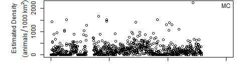

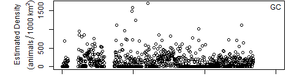

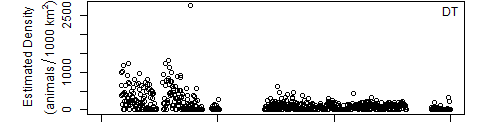

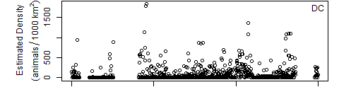

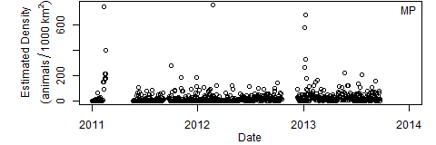

```r
plot.timeseries(siteList,outDir,AcOnlySegments)
```

## Examine Covariates

### Identify Outliers

Replace extreme outliers (bad data) with NaNs.

```r
# Identify and clear problematic outliers
outlierList <-which(mergedSegments$CHL< -10)
mergedSegments$CHL[outlierList] <- NaN
outlierList <-which(mergedSegments$FrontDist_Cayula>800000)
mergedSegments$FrontDist_Cayula[outlierList] <- NaN
outlierList <-which(mergedSegments$Density>10000)
mergedSegments$Density[outlierList] <- NaN

outlierList <-which(AcOnlySegments$CHL< -10)
AcOnlySegments$CHL[outlierList] <- NaN
outlierList <-which(AcOnlySegments$FrontDist_Cayula>800000)
AcOnlySegments$FrontDist_Cayula[outlierList] <- NaN
outlierList <-which(AcOnlySegments$Density>10000)
AcOnlySegments$Density[outlierList] <- NaN

outlierList <-which(VisOnlySegments$CHL<  -10)
VisOnlySegments$CHL[outlierList] <- NaN
outlierList <-which(VisOnlySegments$FrontDist_Cayula>800000)
VisOnlySegments$FrontDist_Cayula[outlierList] <- NaN
outlierList <-which(VisOnlySegments$Density>10000)
VisOnlySegments$Density[outlierList] <- NaN
```

### Check Covariate Distributions

Covariates have different distributions across the observations. Here are the distributions of covariates from the acoustic observations:

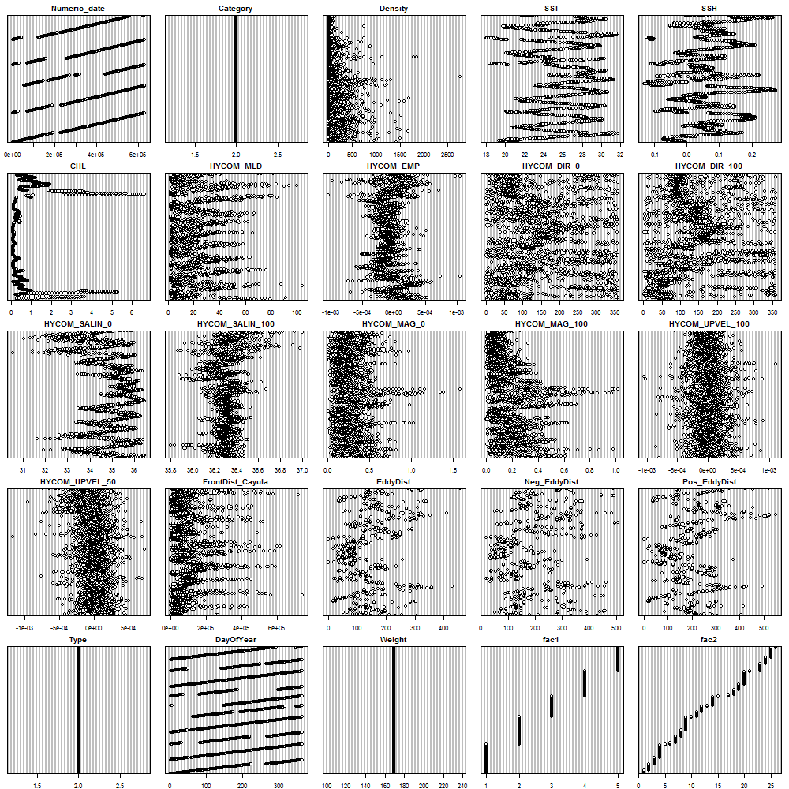

```r
plot.cleveland(mergedTrain.set,covarList,FALSE,paste0(outDir,'AcousticAndVisual_',SP))
plot.cleveland(Train_AcOnly.set,covarList,FALSE,paste0(outDir,'AcousticOnly_',SP))
plot.cleveland(Train_VisOnly.set,covarList,FALSE,paste0(outDir,'VisualOnly_',SP))
```

Here are the distributions of covariates from the visual observations:

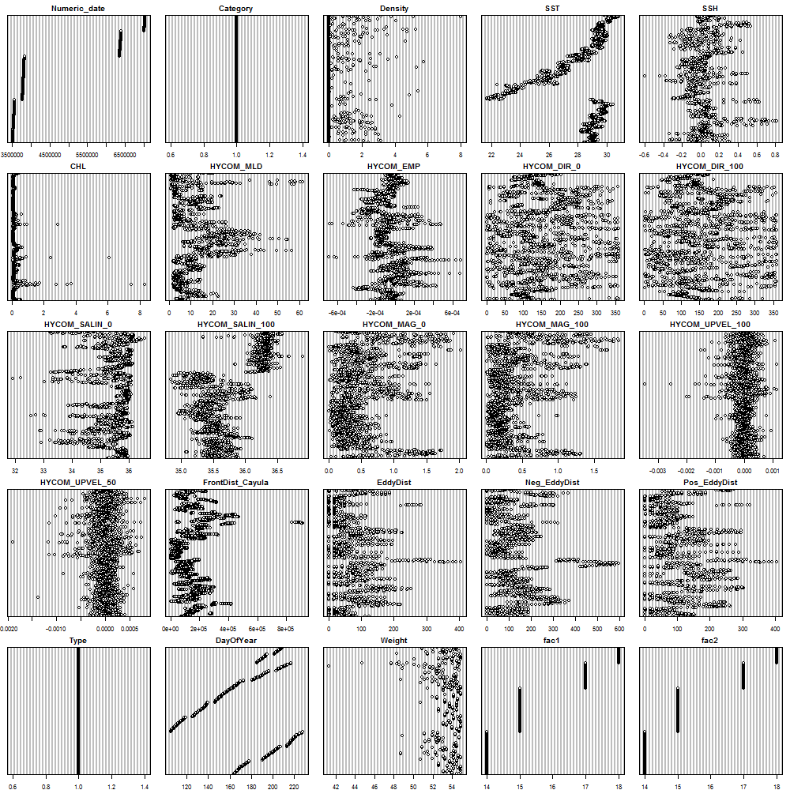

Some of these covariates are more or less interrelated. HYCOM estimates of salinity at the surface (HYCOM_SALIN_0) and at 100m (HYCOM_SALIN_100) are very similar, so I selected surface salinity for simplicity. HYCOM current and upwelling estimates at 100m were also removed (HYCOM_MAG_100,HYCOM_UPVEL_100). HYCOM current direction is site specific in the acoustic data, so it was excluded for now.

Remaining correlations are examined in the figure below. Numbers closer to 1 above the diagonal in the figure below represent correlation coefficients. Highly correlated covariates should not be used together in the same model. Day of year was excluded to avoid artifacts associated with the temporal differences of the datasets (Acoustic data are year-round, and visual data are collected in spring/summer).

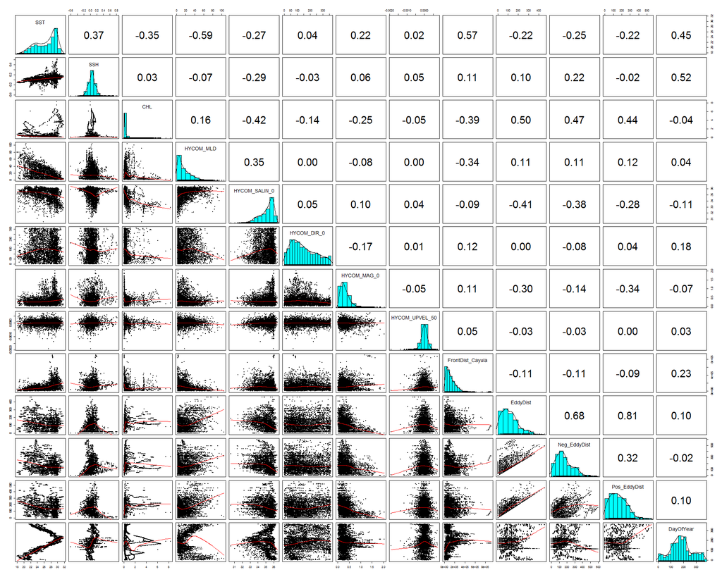

```r
covarList2 <- c("SST","SSH","CHL","HYCOM_MLD",
                "HYCOM_SALIN_0","HYCOM_DIR_0",
                "HYCOM_MAG_0",
                "HYCOM_UPVEL_50","FrontDist_Cayula",
                "EddyDist","Neg_EddyDist","Pos_EddyDist",
                "DayOfYear","fac1","fac2")

# restrict covariates again to limited set
mergedTrain.set2<- mergedTrain.set[,covarList2]
mergedTest.set2<- mergedTest.set[,covarList2]
Train_AcOnly.set2<- Train_AcOnly.set[,covarList2]
Test_AcOnly.set2<- Test_AcOnly.set[,covarList2]
Train_VisOnly.set2<- Train_VisOnly.set[,covarList2]
Test_VisOnly.set2<- Test_VisOnly.set[,covarList2]

# without transform
png(paste(outDir,SP,'_correlations_noTransform.png',sep=''), width = 2000, height = 1600)
pairs.panels(mergedTrain.set2[,1:(length(covarList2)-2)], ellipses=FALSE, method = "spearman",cex.cor=.75)
dev.off()
png(paste(outDir,SP,'_correlations_noTransform_AcOnly.png',sep=''), width = 2000, height = 1600)
pairs.panels(Train_AcOnly.set2[,1:(length(covarList2)-2)], ellipses=FALSE, method = "spearman",cex.cor=.75)
dev.off()
png(paste(outDir,SP,'_correlations_noTransform_visOnly.png',sep=''), width = 2000, height = 1600)
pairs.panels(Train_VisOnly.set2[,1:(length(covarList2)-2)], ellipses=FALSE, method = "spearman",cex.cor=.75)
dev.off()
```

### Transform Predictor Variables

Some variables, including chlorophyll, current magnitude, mixed layer depth and distance to fronts are highly skewed and can be log-transformed.

```r
# covarList2 <- c("SST","SSH","CHL","HYCOM_MLD",
#                 "HYCOM_SALIN_0","HYCOM_DIR_0",
#                 "HYCOM_MAG_0",
#                 "HYCOM_UPVEL_50","FrontDist_Cayula",
#                 "EddyDist","Neg_EddyDist", "PosEddyDist",
#                 "DayOfYear","fac1","fac2")

transformList <- c("none","none","log10","log10",
                   "none","none",
                   "log10",
                   "none","log10",
                   "none","none","none",
                   "none","none","none")

transformedCovars.train <-
  transform.covars(mergedTrain.set2,covarList2,transformList)
transformedCovars.test <-
  transform.covars(mergedTest.set2,covarList2,transformList)

transformedCovars_AcOnly.train <-
  transform.covars(Train_AcOnly.set2,covarList2,transformList)
transformedCovars_AcOnly.test <-
  transform.covars(Test_AcOnly.set2,covarList2,transformList)
transformedCovars_VisOnly.train <-
  transform.covars(Train_VisOnly.set2,covarList2,transformList)
transformedCovars_VisOnly.test <-
  transform.covars(Test_VisOnly.set2,covarList2,transformList)

# Generate correlation plots with transform
png(paste(outDir,SP,'_correlations_withTransform.png',sep=''), width = 2000, height = 1600)
pairs.panels(transformedCovars.train[,1:(length(covarList2)-2)], ellipses=FALSE, method = "spearman",cex.cor=.75)
dev.off()
png(paste(outDir,SP,'_correlations_withTransform_AcOnly.png',sep=''), width = 2000, height = 1600)
pairs.panels(transformedCovars_AcOnly.train[,1:(length(covarList2)-2)], ellipses=FALSE, method = "spearman",cex.cor=.75)
dev.off()
png(paste(outDir,SP,'_correlations_withTransform_visOnly.png',sep=''), width = 2000, height = 1600)
pairs.panels(transformedCovars_VisOnly.train[,1:(length(covarList2)-2)], ellipses=FALSE, method = "spearman",cex.cor=.75)
dev.off()
```

Plotting the transformed variables:

```r
plotCols = colnames(transformedCovars.train)[1:(length(covarList2)-2)]
plot.cleveland(transformedCovars.train,
               plotCols,TRUE,paste0(outDir,'AcousticAndVisual_',SP))
plot.cleveland(transformedCovars_AcOnly.train,
               plotCols,TRUE,paste0(outDir,'AcousticOnly_',SP))
plot.cleveland(transformedCovars_VisOnly.train,
               plotCols,TRUE,paste0(outDir,'VisualOnly_',SP))
```

Below, the two sets of covariates have been combined and transformed.

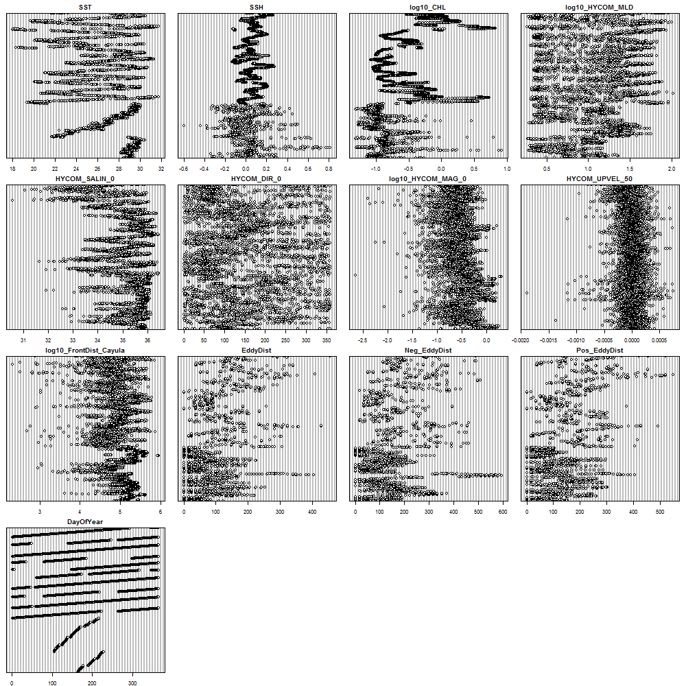

### Check Predictors

To get an idea of the basic predictive power of these covariates, we can look at presence/absence relative to each variable. This also provides an opportunity to look at the range of values observed for each covariate in the visual and acoustic datasets. In the plots below dotted lines indicate the distribution of each covariate when animals were present, and solid lines indicate the distribution when animals were absent. Note that these plots do not account for effort.

```r
plot.covarDensity(transformedCovars.train,
                  colnames(transformedCovars.train),
                  mergedTrain.set$Density,paste0(outDir,'Both_',SP))

plot.covarDensity(transformedCovars_AcOnly.train,
                   colnames(transformedCovars_AcOnly.train),
                  Train_AcOnly.set$Density,paste0(outDir,'AcousticOnly_',SP))

plot.covarDensity(transformedCovars_VisOnly.train,
                  colnames(transformedCovars_VisOnly.train),
                  Train_VisOnly.set$Density,paste0(outDir,'VisualOnly_',SP))
```

Acoustic kernel densities:

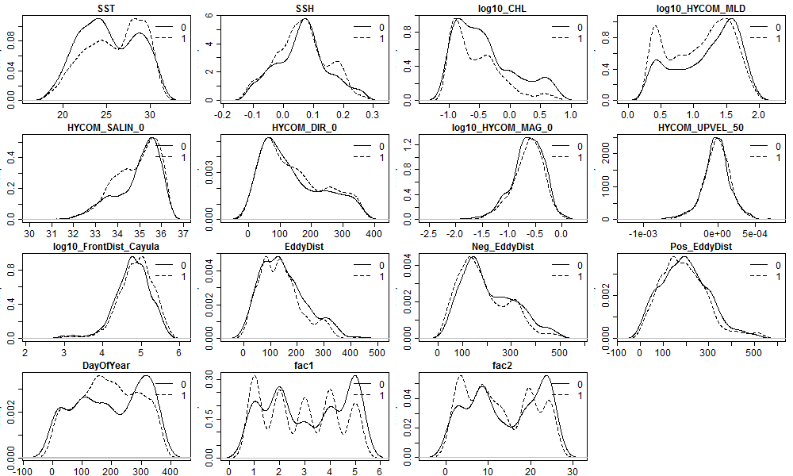

Visual kernel densities:

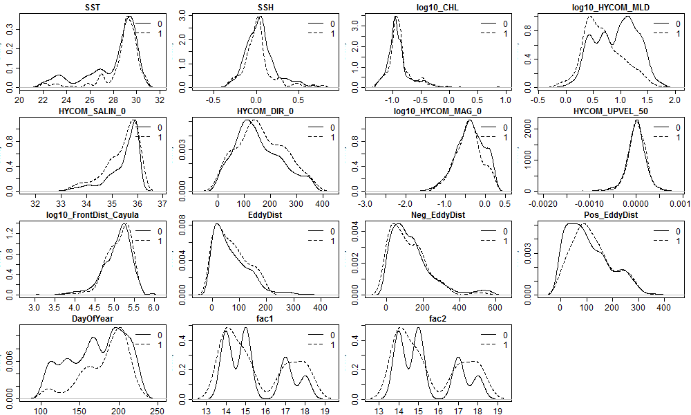

### Estimate Relative Weights

Currently, weights are based on the following logic:

- Acoustic data represent presence in 1 day bins,
- Acoustic data have a maximum detection range of distance of 5km (for dolphins and beaked whales), for a total monitoring area of $(5 km)^{2} \pi$,
- Visual data represent presence during ~10 km transect segments traveling at ~10 knots or ~18.5km/hr. Therefore each visual datapoint represents ~0.54 hours of effort.
- Visual estimated strip width (ESW) varies depending on the conditions. ESW for each sighting is multiplied by trasenct segment length (usually ~10km) and doubled to estimate total area swept.

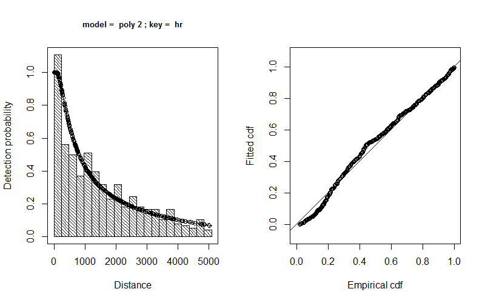

```r
cat(paste0('Mean visual data point weight: ',
           round(mean(Train_VisOnly.set$Weight)),
           '\nAcoustic data point weight: ',
           round(mean(Train_AcOnly.set$Weight))))
```

```
## Mean visual data point weight: 54
## Acoustic data point weight: 170
```

# II. Model Fitting

Models were fit using gamm from the mgcv package in R.

```r
weeklyOccurrenceFile = paste0(outDir,'ALLSITES_weeklyPOccurrence_Ssp_jahStart.csv')
pOccur <- read.csv(weeklyOccurrenceFile, header = TRUE,na.strings=c('',' ','NA','NaN'))
```

Initialize model parameters:

```r
# Run & evaluate models
kVal <- 5 # choose a low value to avoid overfitting

yAcOnly_TF <- as.logical(Train_AcOnly.set$Density >0)
yVisOnly_TF <- as.logical(Train_VisOnly.set$Density >0)
y_TF <- as.logical(mergedTrain.set$Density>0)

 # initialize empty structure for model storage

gamm_full_AcOnly_TF<-NULL
gamm_full_VisOnly_TF<-NULL
gamm_full_TF<-NULL
```

## Determine best family of functions to use:

Binomial or negative binomial?

Try it in a simple glm model.

```r
# Acoustic model
AcOnly_negbin_simple <-glm(yAcOnly_TF~ 1,
                           data = transformedCovars_AcOnly.train,
                           na.action = na.omit,family = nb)
AcOnly_bin_simple <-glm(yAcOnly_TF~ 1,
                        data = transformedCovars_AcOnly.train,
                        na.action = na.omit,family = binomial())

lrtest(AcOnly_negbin_simple,AcOnly_bin_simple)
```

```
## Likelihood ratio test
##
## Model 1: yAcOnly_TF ~ 1
## Model 2: yAcOnly_TF ~ 1
##   #Df  LogLik Df  Chisq Pr(>Chisq)
## 1   1 -3227.4
## 2   1 -1674.6  0 3105.6  < 2.2e-16 ***
## ---
## Signif. codes:  0 '***' 0.001 '**' 0.01 '*' 0.05 '.' 0.1 ' ' 1
```

```r
# Visual model
VisOnly_negbin_simple <-glm(yVisOnly_TF~ 1,
                           data = transformedCovars_VisOnly.train,
                         na.action = na.omit,family = nb)
VisOnly_bin_simple <-glm(yVisOnly_TF~ 1,
                        data = transformedCovars_VisOnly.train,
                        na.action = na.omit,family = binomial())

lrtest(VisOnly_negbin_simple,VisOnly_bin_simple)
```

```
## Likelihood ratio test
##
## Model 1: yVisOnly_TF ~ 1
## Model 2: yVisOnly_TF ~ 1
##   #Df   LogLik Df  Chisq Pr(>Chisq)
## 1   1 -1612.17
## 2   1  -780.56  0 1663.2  < 2.2e-16 ***
## ---
## Signif. codes:  0 '***' 0.001 '**' 0.01 '*' 0.05 '.' 0.1 ' ' 1
```

```r
# Joint model
negbin_simple <-glm(y_TF~ 1,
                           data = transformedCovars.train,
                         na.action = na.omit,family = nb)
bin_simple <-glm(y_TF~ 1,
                        data = transformedCovars.train,
                        na.action = na.omit,family = binomial())

lrtest(negbin_simple,bin_simple)
```

```
## Likelihood ratio test
##
## Model 1: y_TF ~ 1
## Model 2: y_TF ~ 1
##   #Df  LogLik Df  Chisq Pr(>Chisq)
## 1   1 -4787.9
## 2   1 -3249.1  0 3077.4  < 2.2e-16 ***
## ---
## Signif. codes:  0 '***' 0.001 '**' 0.01 '*' 0.05 '.' 0.1 ' ' 1
```

In all cases, the best null model (lowest likelihood ratio and degrees of freedom) is the binomial model.

## Run Full Models

Run full binomial GAMs on Acoustic only, Visual only, and joint Acoustic/Visual datasets.

Models have the following characteristics: - Binomial distribution, - corAR1 correlation structure, - ts splines

### Model 1

Use distance to positive eddies:

```r
gamm_full_AcOnly_TF$v01 <- gamm(yAcOnly_TF ~ s(SST, bs='ts', k=kVal)
                               + s(SSH, bs='ts', k=kVal)
                               + s(log10_CHL, bs='ts', k=kVal)
                               + s(Pos_EddyDist, bs='ts', k=kVal)
                               + s(HYCOM_SALIN_0,bs='ts', k=kVal)
                               + s(log10_HYCOM_MLD, bs='ts', k=kVal),
                               data = transformedCovars_AcOnly.train,
                               na.action = na.omit,family =  quasibinomial(),
                               correlation = corAR1(form=~1|fac2))#
```

```r
gamm_full_VisOnly_TF$v01 <- gamm(yVisOnly_TF~ s(SST, bs='ts', k=kVal)
                               + s(SSH, bs='ts', k=kVal)
                               + s(log10_HYCOM_MAG_0,bs='ts', k=kVal)
                               + s(HYCOM_SALIN_0,bs='ts', k=kVal)
                               + s(Pos_EddyDist, bs='ts', k=kVal)
                               + s(log10_HYCOM_MLD, bs='ts', k=kVal),
                               data = transformedCovars_VisOnly.train,
                               na.action = na.omit,family =  quasibinomial(),
                               correlation = corAR1(form=~1|fac2))


gamm_full_TF$v01 <- gamm(y_TF~ s(SST, bs='ts', k=kVal)
                        + s(SSH, bs='ts', k=kVal)
                        + s(log10_CHL, bs='ts', k=kVal)
                        + s(log10_HYCOM_MAG_0,bs='ts', k=kVal)
                        + s(HYCOM_SALIN_0, bs='ts', k=kVal)
                        + s(log10_HYCOM_MLD, bs='ts', k=kVal),
                        data = transformedCovars.train,
                        weights = mergedTrain.set$Weight/mean(mergedTrain.set$Weight),
                        na.action = na.omit,family = quasibinomial(),
                        correlation = corAR1(form=~1|fac2),niterPQL = 50)
```

### Model 2

Try eddy distance and SSH as an interaction term:

```r
gamm_full_AcOnly_TF$v02 <- gamm(yAcOnly_TF~ s(SST, bs='ts', k=kVal)
                               + s(log10_CHL, bs='ts', k=kVal)
                               + s(SSH, EddyDist, bs='ts', k=kVal)
                               + s(HYCOM_SALIN_0,bs='ts', k=kVal)
                               + s(log10_HYCOM_MLD, bs='ts', k=kVal),
                               data = transformedCovars_AcOnly.train,
                               na.action = na.omit,family = quasibinomial(),
                               correlation = corAR1(form=~1|fac2))
```

```r
gamm_full_VisOnly_TF$v02 <- gamm(yVisOnly_TF~ s(SST, bs='ts', k=kVal)
                               + s(SSH, EddyDist, bs='ts', k=kVal)
                               + s(log10_HYCOM_MAG_0,bs='ts', k=kVal)
                               + s(HYCOM_SALIN_0,bs='ts', k=kVal)
                               + s(log10_HYCOM_MLD, bs='ts', k=kVal),
                               data = transformedCovars_VisOnly.train,
                               na.action = na.omit,family = quasibinomial(),
                               correlation = corAR1(form=~1|fac2))


gamm_full_TF$v02 <- gamm(y_TF~ s(SST, bs='ts', k=kVal)
                        + s(log10_CHL, bs='ts', k=kVal)
                        + s(SSH, EddyDist,  bs='ts', k=kVal)
                        + s(HYCOM_SALIN_0, bs='ts', k=kVal)
                        + s(log10_HYCOM_MLD, bs='ts', k=kVal),
                        data = transformedCovars.train,
                        weights = mergedTrain.set$Weight/mean(mergedTrain.set$Weight),
                        na.action = na.omit,family = quasibinomial(),
                        correlation = corAR1(form=~1|fac2),niterPQL = 50)
```

Done trying different model configurations for now, time to compare the results.

# III. Model Comparisons

Look at AIC to select best acoustic-only model:

```r
AC_model_AIC <- NULL
for (iMod in 1:length(gamm_full_AcOnly_TF)){
  AC_model_AIC[iMod] <- AIC(gamm_full_AcOnly_TF[[iMod]]$lme)
  cat('Model ', names(gamm_full_AcOnly_TF[iMod]), ' AIC = ', AC_model_AIC[iMod], '\n')
}
```

```
## Model  v01  AIC =  13149.19
## Model  v02  AIC =  13147.81
```

```r
best_AcOnly_model_index <- which.min(AC_model_AIC)
best_AcOnly_model <- gamm_full_AcOnly_TF[[best_AcOnly_model_index]]
best_AcOnly_model_name <- names(gamm_full_AcOnly_TF[best_AcOnly_model_index])

cat('Best acoustic only model is ', best_AcOnly_model_name,' \n')
```

```
## Best acoustic only model is  v02
```

Look at AIC to select best visual-only model:

```r
Vis_model_AIC <- NULL
for (iMod in 1:length(gamm_full_VisOnly_TF)){
  Vis_model_AIC[iMod] <- AIC(gamm_full_VisOnly_TF[[iMod]]$lme)
  cat('Model ', names(gamm_full_VisOnly_TF[iMod]), ' AIC = ', Vis_model_AIC[iMod], '\n')
}
```

```
## Model  v01  AIC =  10399.47
## Model  v02  AIC =  10382.45
```

```r
best_VisOnly_model_index <- which.min(Vis_model_AIC)
best_VisOnly_model <- gamm_full_VisOnly_TF[[best_VisOnly_model_index]]
best_VisOnly_model_name <- names(gamm_full_VisOnly_TF[best_VisOnly_model_index])

cat('Best visual only model is ', best_VisOnly_model_name,' \n')
```

```
## Best visual only model is  v02
```

Look at AIC to select best joint model:

```r
model_AIC <- NULL
for (iMod in 1:length(gamm_full_TF)){
  model_AIC[iMod] <- AIC(gamm_full_TF[[iMod]]$lme)
  cat('Model ', names(gamm_full_TF[iMod]), ' AIC = ', model_AIC[iMod], '\n')
}
```

```
## Model  v01  AIC =  20169.48
## Model  v02  AIC =  20103.87
```

```r
best_model_index <- which.min(model_AIC)
best_model <- gamm_full_TF[[best_model_index]]
best_model_name <- names(gamm_full_TF[best_model_index])


cat('Best joint visual and acoustic model is ', best_model_name,' \n')
```

```
## Best joint visual and acoustic model is  v02
```

## Best Acoustic Only Model

```r
summary(best_AcOnly_model$gam)
```

```
##
## Family: quasibinomial
## Link function: logit
##
## Formula:
## yAcOnly_TF ~ s(SST, bs = "ts", k = kVal) + s(log10_CHL, bs = "ts",
##     k = kVal) + s(SSH, EddyDist, bs = "ts", k = kVal) + s(HYCOM_SALIN_0,
##     bs = "ts", k = kVal) + s(log10_HYCOM_MLD, bs = "ts", k = kVal)
##
## Parametric coefficients:
##             Estimate Std. Error t value Pr(>|t|)
## (Intercept)  1.09636    0.05389   20.34   <2e-16 ***
## ---
## Signif. codes:  0 '***' 0.001 '**' 0.01 '*' 0.05 '.' 0.1 ' ' 1
##
## Approximate significance of smooth terms:
##                       edf Ref.df      F  p-value
## s(SST)             1.8360      4  2.363 0.002190 **
## s(log10_CHL)       2.6343      4 16.467  < 2e-16 ***
## s(SSH,EddyDist)    1.7655      4  3.620 0.000219 ***
## s(HYCOM_SALIN_0)   0.9332      4  1.792 0.003853 **
## s(log10_HYCOM_MLD) 0.8269      4  1.002 0.023828 *
## ---
## Signif. codes:  0 '***' 0.001 '**' 0.01 '*' 0.05 '.' 0.1 ' ' 1
##
## R-sq.(adj) =  0.0495
##   Scale est. = 0.97909   n = 2918
```

Re-run the best acoustic-only model with only the significant terms

```r
AcOnly_gamm_pruned_TF_best <- gamm(yAcOnly_TF ~ s(SST, bs='ts', k=kVal)
                                      + s(log10_CHL, bs='ts', k=kVal)
                                      + s(SSH,EddyDist, bs='ts', k=kVal)
                                      + s(HYCOM_SALIN_0,bs='ts', k=kVal)
                                      + s(log10_HYCOM_MLD,bs='ts', k=kVal),
                                      data = transformedCovars_AcOnly.train,
                                      na.action = na.omit,family = quasibinomial(),
                                      correlation = corAR1(form=~1|fac2))
```

```r
summary(AcOnly_gamm_pruned_TF_best$gam)
```

```
##
## Family: quasibinomial
## Link function: logit
##
## Formula:
## yAcOnly_TF ~ s(SST, bs = "ts", k = kVal) + s(log10_CHL, bs = "ts",
##     k = kVal) + s(SSH, EddyDist, bs = "ts", k = kVal) + s(HYCOM_SALIN_0,
##     bs = "ts", k = kVal) + s(log10_HYCOM_MLD, bs = "ts", k = kVal)
##
## Parametric coefficients:
##             Estimate Std. Error t value Pr(>|t|)
## (Intercept)  1.09636    0.05389   20.34   <2e-16 ***
## ---
## Signif. codes:  0 '***' 0.001 '**' 0.01 '*' 0.05 '.' 0.1 ' ' 1
##
## Approximate significance of smooth terms:
##                       edf Ref.df      F  p-value
## s(SST)             1.8360      4  2.363 0.002190 **
## s(log10_CHL)       2.6343      4 16.467  < 2e-16 ***
## s(SSH,EddyDist)    1.7655      4  3.620 0.000219 ***
## s(HYCOM_SALIN_0)   0.9332      4  1.792 0.003853 **
## s(log10_HYCOM_MLD) 0.8269      4  1.002 0.023828 *
## ---
## Signif. codes:  0 '***' 0.001 '**' 0.01 '*' 0.05 '.' 0.1 ' ' 1
##
## R-sq.(adj) =  0.0495
##   Scale est. = 0.97909   n = 2918
```

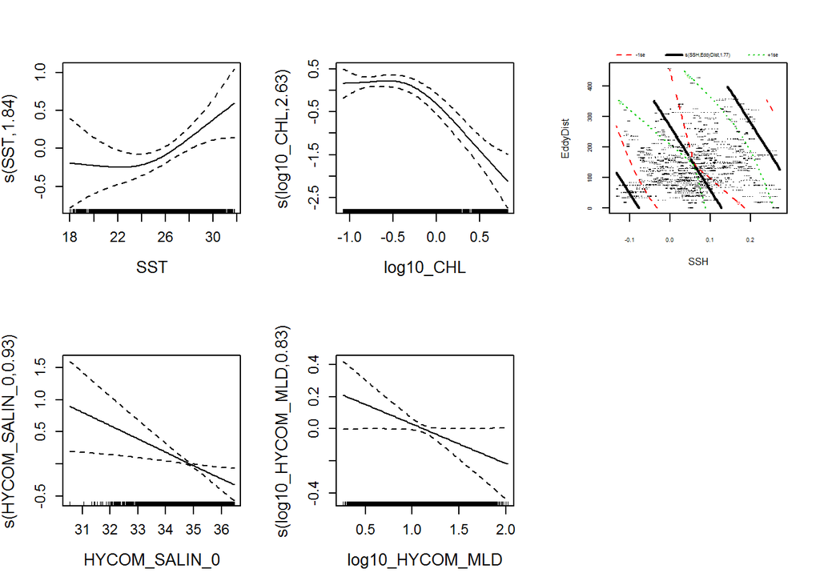

```r
plot(AcOnly_gamm_pruned_TF_best$gam,pages=1,cex.lab = 1.3,cex.axis = 1.1,scale=0)
```

```r
save(AcOnly_gamm_pruned_TF_best,file = paste(outDir,SP,'_best_AcOnly_binomial_model.Rdata',sep=''))
```

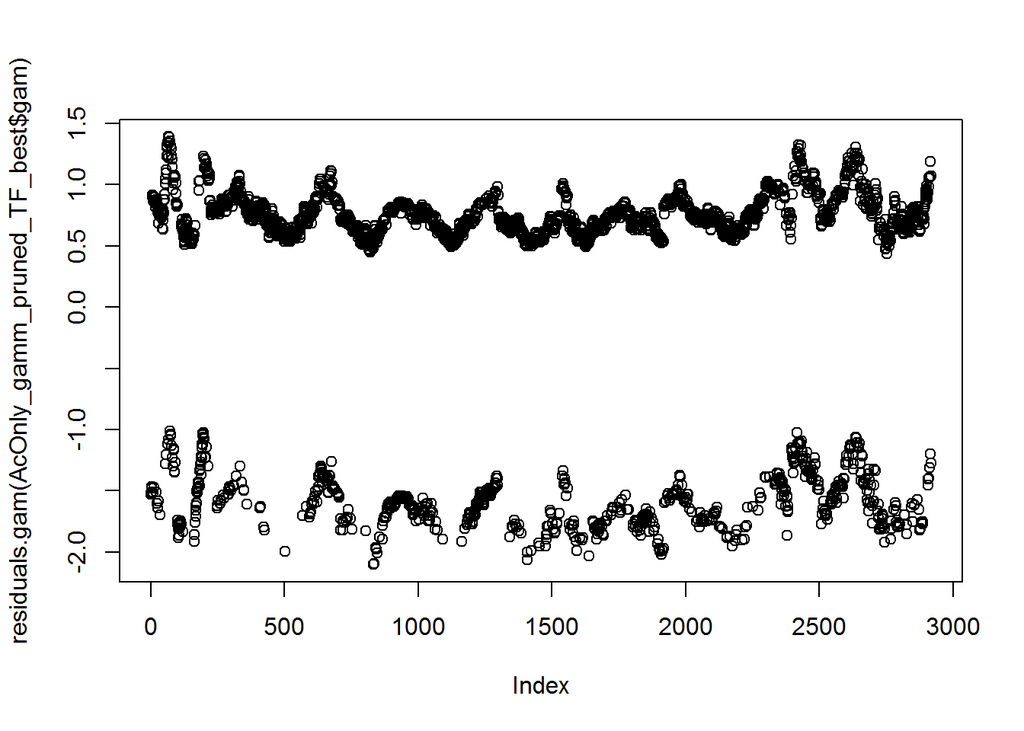

```r
plot(residuals.gam(AcOnly_gamm_pruned_TF_best$gam))
```

```r
# gam.check(AcOnly_gamm_pruned_TF_best$gam)
```

## Best Visual Only Model

```r
summary(best_VisOnly_model$gam)
```

```
##
## Family: quasibinomial
## Link function: logit
##
## Formula:
## yVisOnly_TF ~ s(SST, bs = "ts", k = kVal) + s(SSH, EddyDist,
##     bs = "ts", k = kVal) + s(log10_HYCOM_MAG_0, bs = "ts", k = kVal) +
##     s(HYCOM_SALIN_0, bs = "ts", k = kVal) + s(log10_HYCOM_MLD,
##     bs = "ts", k = kVal)
##
## Parametric coefficients:
##             Estimate Std. Error t value Pr(>|t|)
## (Intercept) -2.04729    0.08387  -24.41   <2e-16 ***
## ---
## Signif. codes:  0 '***' 0.001 '**' 0.01 '*' 0.05 '.' 0.1 ' ' 1
##
## Approximate significance of smooth terms:
##                            edf Ref.df      F  p-value
## s(SST)               0.3121390      4  0.113   0.2182
## s(SSH,EddyDist)      1.3063575      4  0.932   0.0544 .
## s(log10_HYCOM_MAG_0) 0.1936356      4  0.060   0.2590
## s(HYCOM_SALIN_0)     0.0001637      4  0.000   0.3132
## s(log10_HYCOM_MLD)   1.2162758      4 13.620 8.91e-15 ***
## ---
## Signif. codes:  0 '***' 0.001 '**' 0.01 '*' 0.05 '.' 0.1 ' ' 1
##
## R-sq.(adj) =  0.0467
##   Scale est. = 0.98447   n = 2015
```

Re-run the best visual-only model with only the significant term(s).

```r
VisOnly_gamm_pruned_TF_best <- gamm(yVisOnly_TF~ s(SSH,EddyDist, bs='ts', k=kVal)
                               + s(log10_HYCOM_MLD, bs='ts', k=kVal),
                               data = transformedCovars_VisOnly.train,
                               na.action = na.omit,family = quasibinomial(),
                               correlation = corAR1(form=~1|fac2))
```

```r
summary(VisOnly_gamm_pruned_TF_best$gam)
```

```
##
## Family: quasibinomial
## Link function: logit
##
## Formula:
## yVisOnly_TF ~ s(SSH, EddyDist, bs = "ts", k = kVal) + s(log10_HYCOM_MLD,
##     bs = "ts", k = kVal)
##
## Parametric coefficients:
##             Estimate Std. Error t value Pr(>|t|)
## (Intercept) -2.04612    0.08388  -24.39   <2e-16 ***
## ---
## Signif. codes:  0 '***' 0.001 '**' 0.01 '*' 0.05 '.' 0.1 ' ' 1
##
## Approximate significance of smooth terms:
##                      edf Ref.df      F  p-value
## s(SSH,EddyDist)    1.284      4  0.879   0.0651 .
## s(log10_HYCOM_MLD) 1.238      4 16.067 4.81e-16 ***
## ---
## Signif. codes:  0 '***' 0.001 '**' 0.01 '*' 0.05 '.' 0.1 ' ' 1
##
## R-sq.(adj) =  0.046
##   Scale est. = 0.98568   n = 2015
```

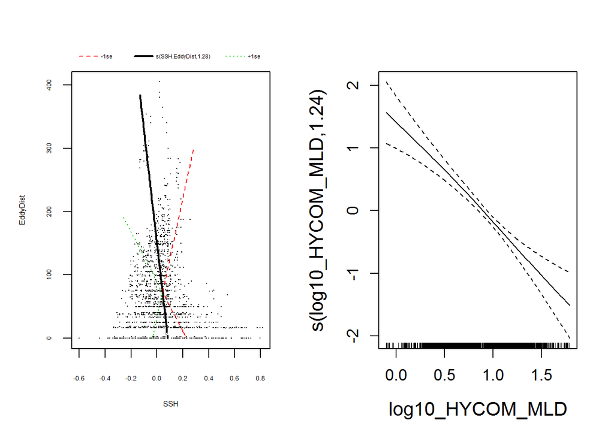

```r
plot(VisOnly_gamm_pruned_TF_best$gam,pages=1,cex.lab = 1.3,cex.axis = 1.1,scale=0)
```

```r
save(VisOnly_gamm_pruned_TF_best,file = paste(outDir,SP,'_best_VisOnly_binomial_model.Rdata',sep=''))
```

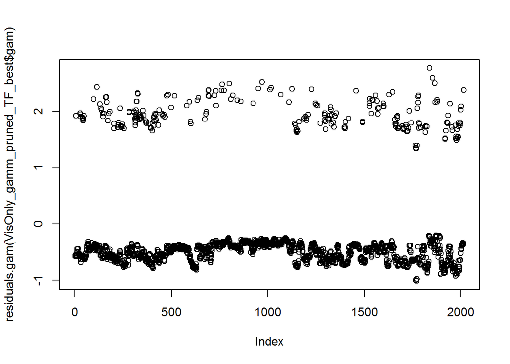

```r
plot(residuals.gam(VisOnly_gamm_pruned_TF_best$gam))
```

```r
# gam.check(VisOnly_gamm_pruned_TF_best$gam)
```

## Best Joint Visual & Acoustic Model

```r
summary(best_model$gam)
```

```
##
## Family: quasibinomial
## Link function: logit
##
## Formula:
## y_TF ~ s(SST, bs = "ts", k = kVal) + s(log10_CHL, bs = "ts",
##     k = kVal) + s(SSH, EddyDist, bs = "ts", k = kVal) + s(HYCOM_SALIN_0,
##     bs = "ts", k = kVal) + s(log10_HYCOM_MLD, bs = "ts", k = kVal)
##
## Parametric coefficients:
##             Estimate Std. Error t value Pr(>|t|)
## (Intercept)  0.52917    0.04584   11.54   <2e-16 ***
## ---
## Signif. codes:  0 '***' 0.001 '**' 0.01 '*' 0.05 '.' 0.1 ' ' 1
##
## Approximate significance of smooth terms:
##                          edf Ref.df      F  p-value
## s(SST)             7.616e-01      4  0.695   0.0484 *
## s(log10_CHL)       3.453e+00      4 16.746 9.69e-16 ***
## s(SSH,EddyDist)    1.751e-05      4  0.000   0.5943
## s(HYCOM_SALIN_0)   3.340e+00      4 12.143 1.82e-11 ***
## s(log10_HYCOM_MLD) 6.500e-01      4  0.459   0.0852 .
## ---
## Signif. codes:  0 '***' 0.001 '**' 0.01 '*' 0.05 '.' 0.1 ' ' 1
##
## R-sq.(adj) =  0.0593
##   Scale est. = 0.99414   n = 4629
```

Re-run the best joint model with only the significant terms

```r
gamm_pruned_TF_best <- gamm(y_TF~ s(SST, bs='ts', k=kVal)
                        + s(log10_CHL, bs='ts', k=kVal)
                        + s(HYCOM_SALIN_0,bs='ts', k=kVal)
                        + s(log10_HYCOM_MLD, bs='ts', k=kVal),
                        data = transformedCovars.train,
                        weights = mergedTrain.set$Weight/mean(mergedTrain.set$Weight),
                        na.action = na.omit,family = quasibinomial(),
                        correlation = corAR1(form=~1|fac2),niterPQL = 30)
```

```r
summary(gamm_pruned_TF_best$gam)
```

```
##
## Family: quasibinomial
## Link function: logit
##
## Formula:
## y_TF ~ s(SST, bs = "ts", k = kVal) + s(log10_CHL, bs = "ts",
##     k = kVal) + s(HYCOM_SALIN_0, bs = "ts", k = kVal) + s(log10_HYCOM_MLD,
##     bs = "ts", k = kVal)
##
## Parametric coefficients:
##             Estimate Std. Error t value Pr(>|t|)
## (Intercept)  0.52917    0.04584   11.54   <2e-16 ***
## ---
## Signif. codes:  0 '***' 0.001 '**' 0.01 '*' 0.05 '.' 0.1 ' ' 1
##
## Approximate significance of smooth terms:
##                       edf Ref.df      F  p-value
## s(SST)             0.7616      4  0.695   0.0484 *
## s(log10_CHL)       3.4531      4 16.746 9.69e-16 ***
## s(HYCOM_SALIN_0)   3.3401      4 12.143 1.82e-11 ***
## s(log10_HYCOM_MLD) 0.6499      4  0.459   0.0852 .
## ---
## Signif. codes:  0 '***' 0.001 '**' 0.01 '*' 0.05 '.' 0.1 ' ' 1
##
## R-sq.(adj) =  0.0593
##   Scale est. = 0.99415   n = 4629
```

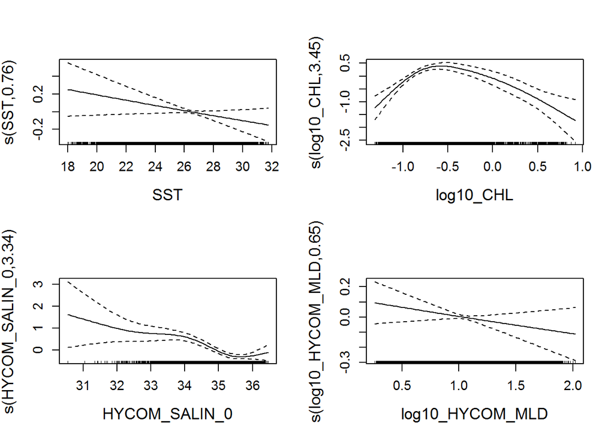

```r
plot(gamm_pruned_TF_best$gam,pages=1,cex.lab = 1.3,cex.axis = 1.1,scale=0)
```

```r
save(gamm_pruned_TF_best,file = paste(outDir,SP,'_best_joint_binomial_model.Rdata',sep=''))
```

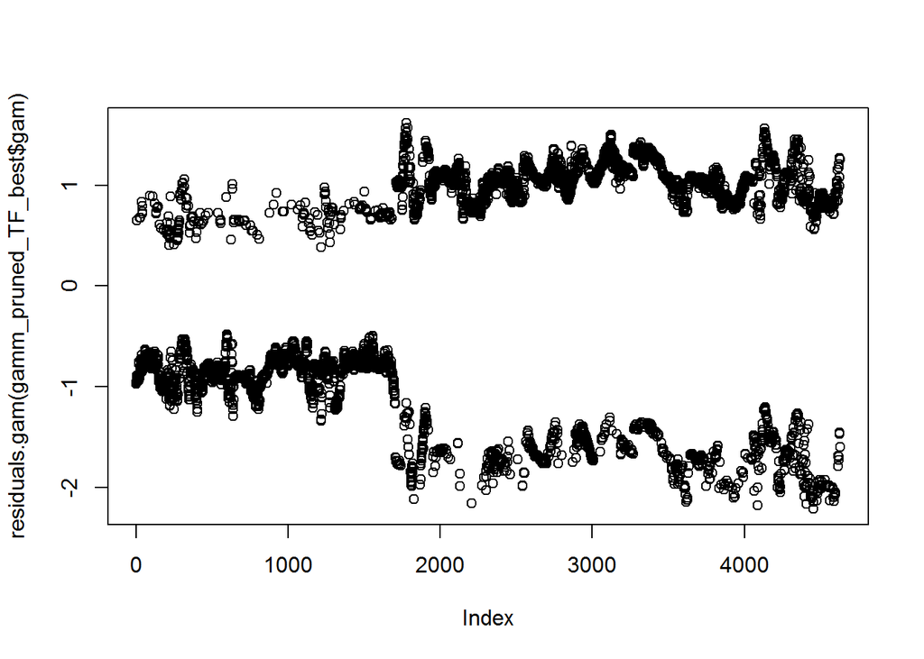

```r
plot(residuals.gam(gamm_pruned_TF_best$gam))
```

```r
# gam.check(gamm_pruned_TF_best$gam)
```

# IV. Predict on Test Data

## Temporal prediction

### Acoustic Only Model

Predict on acoustic test data, and compare with actual observations for 2013. We are comparing the predicted probability of encountering animals with the actual weekly rate of occurrence of animals at a site.

CAVEAT: Encounter probability from the data is estimated as fraction of days per week during which Risso’s were detected. This results in a pretty coarse estimate. Alternatively we could compare to daily densities or something, but then the y-axis scales are completely different and it may be an apples to oranges comparison. An earlier version used densities, and seemed to suggest that lagging variables might be appropriate…

```r
# Predict on acoustic test data, using acoustic only model for comparison...
compAcSet_MC <- which((Test_AcOnly.set$fac2)==5)
compAcSet_GC <- which((Test_AcOnly.set$fac2)==10)
compAcSet_DT <- which((Test_AcOnly.set$fac2)==15 |
                        (Test_AcOnly.set$fac2)==16)
compAcSet_DC <- which((Test_AcOnly.set$fac2)==21 |
                        (Test_AcOnly.set$fac2)==22)
compAcSet_MP <- which((Test_AcOnly.set$fac2)==26)

# Predict in time
dateTicks = as.POSIXct(c('2013-01-01 GMT','2013-04-01 GMT',
                         '2013-07-01 GMT','2013-10-01 GMT',
                         '2014-01-01 GMT'))
dateLabels = c('Jan. 2013','Apr. 2013','Jul. 2013','Oct 2013','Jan. 2014')
predAcOnly_MC <- predict.gam(AcOnly_gamm_pruned_TF_best$gam,
                             transformedCovars_AcOnly.test[compAcSet_MC,],
                             type = 'response',na.action = na.pass)
predAcOnly_GC <- predict.gam(AcOnly_gamm_pruned_TF_best$gam,
                             transformedCovars_AcOnly.test[compAcSet_GC,],
                             type = 'response',na.action = na.pass)
predAcOnly_DT <- predict.gam(AcOnly_gamm_pruned_TF_best$gam,
                             transformedCovars_AcOnly.test[compAcSet_DT,],
                            type = 'response',na.action = na.pass)
predAcOnly_DC <- predict.gam(AcOnly_gamm_pruned_TF_best$gam,
                             transformedCovars_AcOnly.test[compAcSet_DC,],
                             type = 'response',na.action = na.pass)
predAcOnly_MP <- predict.gam(AcOnly_gamm_pruned_TF_best$gam,
                             transformedCovars_AcOnly.test[compAcSet_MP,],
                             type = 'response',na.action = na.pass)
occurIdx = which(as.POSIXct(pOccur[,1])>='2013-01-01' & as.POSIXct(pOccur[,1])<'2014-01-01')


AcOnly_predictionSet <- data.frame(unique(Test_AcOnly.set$date))
colnames(AcOnly_predictionSet) <-"date"
AcOnly_predictionSet$MC <- NA
MC_times <- Test_AcOnly.set$date[compAcSet_MC]
m1 <- match(MC_times,AcOnly_predictionSet$date)
AcOnly_predictionSet$MC[m1] <-predAcOnly_MC

AcOnly_predictionSet$GC <- NA
GC_times <- Test_AcOnly.set$date[compAcSet_GC]
m2 <- match(GC_times,AcOnly_predictionSet$date)
AcOnly_predictionSet$GC[m2] <-predAcOnly_GC

AcOnly_predictionSet$DT <- NA
DT_times <- Test_AcOnly.set$date[compAcSet_DT]
m3 <- match(DT_times,AcOnly_predictionSet$date)
AcOnly_predictionSet$DT[m3] <-predAcOnly_DT

AcOnly_predictionSet$DC <- NA
DC_times <- Test_AcOnly.set$date[compAcSet_DC]
m4 <- match(DC_times,AcOnly_predictionSet$date)
AcOnly_predictionSet$DC[m4] <-predAcOnly_DC

AcOnly_predictionSet$MP <- NA
MP_times <- Test_AcOnly.set$date[compAcSet_MP]
m5 <- match(MP_times,AcOnly_predictionSet$date)
AcOnly_predictionSet$MP[m5] <-predAcOnly_MP

AcOnly_predictionSet$Legend <- "Predictions"

pOccur$Legend <- "Observations"
```

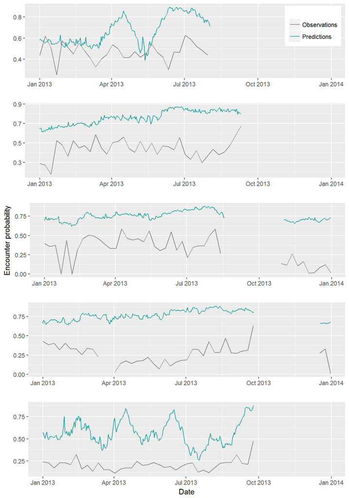

```r
# par(mfrow = c(5,1),oma=c(3,0,5,0)),colour="#000099",colour="#CC0000"
p1_Ac <- ggplot() +
  geom_line(data = pOccur[occurIdx,],
             aes(x = as.POSIXct(dateStr), y = MC, color = Legend))+
  geom_line(data = AcOnly_predictionSet,
            aes(x=date, y=MC, color = Legend)) +
  labs(y = "", x = "")+
  scale_color_manual("",values= c("gray48","#009999"))+
  theme(legend.position = c(0.9, 0.7))

p2_Ac <- ggplot() +
  geom_line(data = pOccur[occurIdx,],
             aes(x =as.POSIXct(dateStr), y = GC, color = Legend))+
  geom_line(data = AcOnly_predictionSet,
            aes(x=date, y=GC, color = Legend))+
  scale_color_manual("",values= c("gray48","#009999"))+
  labs(y = "", x = "")+
  theme(legend.position="none")

p3_Ac <- ggplot() +
  geom_line(data = pOccur[occurIdx,],
             aes(x =as.POSIXct(dateStr), y = DT, color = Legend))+
  geom_line(data = AcOnly_predictionSet,
            aes(x=date, y=DT, color = Legend)) +
  scale_color_manual("",values= c("gray48","#009999"))+
  labs(y = "Encounter probability", x = "")+
  theme(legend.position="none")

p4_Ac <- ggplot() +
  geom_line(data = pOccur[occurIdx,],
             aes(x =as.POSIXct(dateStr), y = DC, color = Legend))+
  geom_line(data = AcOnly_predictionSet,
            aes(x=date, y=DC, color = Legend)) +
  scale_color_manual("",values= c("gray48","#009999"))+
  labs(y = "", x = "")+
  theme(legend.position="none")

p5_Ac <- ggplot() +
  geom_line(data = pOccur[occurIdx,],
             aes(x =as.POSIXct(dateStr), y = MP, color = Legend))+
  geom_line(data = AcOnly_predictionSet,
            aes(x=date, y=MP, color = Legend))+
  scale_color_manual("",values= c("gray48","#009999"))+
  labs(y = "", x = "Date")+
  theme(legend.position="none")

multiplot(p1_Ac, p2_Ac, p3_Ac, p4_Ac, p5_Ac, cols=1)
```

### Visual Only Model

```r
# Confusing, but acoustic only predictors are passed in to since
# we're predicting on the acoustic timeseries.
predVisOnly_MC <- predict.gam(VisOnly_gamm_pruned_TF_best$gam,
                              transformedCovars_AcOnly.test[compAcSet_MC,],
                              type = 'response',na.action = na.pass)
predVisOnly_GC <- predict.gam(VisOnly_gamm_pruned_TF_best$gam,
                              transformedCovars_AcOnly.test[compAcSet_GC,],
                              type = 'response',na.action = na.pass)
predVisOnly_DT <- predict.gam(VisOnly_gamm_pruned_TF_best$gam,
                              transformedCovars_AcOnly.test[compAcSet_DT,],
                              type = 'response',na.action = na.pass)
predVisOnly_DC <- predict.gam(VisOnly_gamm_pruned_TF_best$gam,
                              transformedCovars_AcOnly.test[compAcSet_DC,],
                              type = 'response',na.action = na.pass)
predVisOnly_MP <- predict.gam(VisOnly_gamm_pruned_TF_best$gam,
                              transformedCovars_AcOnly.test[compAcSet_MP,],
                              type = 'response',na.action = na.pass)

VisOnly_predictionSet <- data.frame(unique(Test_AcOnly.set$date))
colnames(VisOnly_predictionSet) <-"date"
VisOnly_predictionSet$MC <- NA
m1 <- match(MC_times,VisOnly_predictionSet$date)
VisOnly_predictionSet$MC[m1] <-predVisOnly_MC

VisOnly_predictionSet$GC <- NA
m2 <- match(GC_times,VisOnly_predictionSet$date)
VisOnly_predictionSet$GC[m2] <-predVisOnly_GC

VisOnly_predictionSet$DT <- NA
m3 <- match(DT_times,VisOnly_predictionSet$date)
VisOnly_predictionSet$DT[m3] <-predVisOnly_DT

VisOnly_predictionSet$DC <- NA
m4 <- match(DC_times,VisOnly_predictionSet$date)
VisOnly_predictionSet$DC[m4] <-predVisOnly_DC

VisOnly_predictionSet$MP <- NA
m5 <- match(MP_times,VisOnly_predictionSet$date)
VisOnly_predictionSet$MP[m5] <-predVisOnly_MP

VisOnly_predictionSet$Legend <- "Predictions"
```

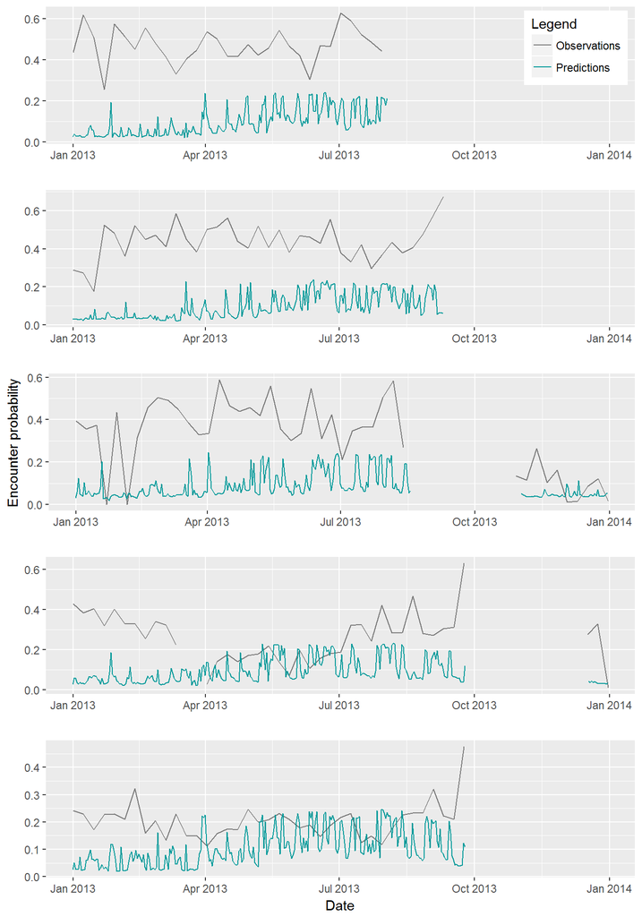

```r
# par(mfrow = c(5,1),oma=c(3,0,5,0)),colour="#000099",colour="#CC0000"
p1_Vis <- ggplot() +
  geom_line(data = pOccur[occurIdx,],
             aes(x = as.POSIXct(dateStr), y = MC, color = Legend))+
  geom_line(data = VisOnly_predictionSet,
            aes(x=date, y=MC, color = Legend)) +
  labs(y = "", x = "")+
  scale_color_manual(values= c("gray48","#009999"))+
  theme(legend.position = c(0.9, 0.7))

p2_Vis <- ggplot() +
  geom_line(data = pOccur[occurIdx,],
             aes(x =as.POSIXct(dateStr), y = GC, color = Legend))+
  geom_line(data = VisOnly_predictionSet,
            aes(x=date, y=GC, color = Legend)) +
  scale_color_manual(values= c("gray48","#009999"))+
  labs(y = "", x = "")+
  theme(legend.position="none")

p3_Vis <- ggplot() +
  geom_line(data = pOccur[occurIdx,],
             aes(x =as.POSIXct(dateStr), y = DT, color = Legend))+
    geom_line(data = VisOnly_predictionSet,
            aes(x=date, y=DT, color = Legend)) +
  scale_color_manual(values= c("gray48","#009999"))+
  labs(y = "Encounter probability", x = "")+
  theme(legend.position="none")

p4_Vis <- ggplot() +
  geom_line(data = pOccur[occurIdx,],
             aes(x =as.POSIXct(dateStr), y = DC, color = Legend))+
  geom_line(data = VisOnly_predictionSet,
            aes(x=date, y=DC, color = Legend)) +
  scale_color_manual(values= c("gray48","#009999"))+
  labs(y = "", x = "")+
  theme(legend.position="none")

p5_Vis <- ggplot() +
  geom_line(data = pOccur[occurIdx,],
             aes(x =as.POSIXct(dateStr), y = MP, color = Legend))+
  geom_line(data = VisOnly_predictionSet,
            aes(x=date, y=MP, color = Legend))+
  scale_color_manual(values= c("gray48","#009999"))+
  labs(y = "", x = "Date")+
  theme(legend.position="none")

multiplot(p1_Vis, p2_Vis, p3_Vis, p4_Vis, p5_Vis, cols=1)
```

### Joint Model

```r
# Confusing, but acoustic only predictors are passed in to since we're predicting on the acoustic timeseries.
pred_MC <- predict.gam(gamm_pruned_TF_best$gam,
                              transformedCovars_AcOnly.test[compAcSet_MC,],
                              type = 'response',na.action = na.pass)
pred_GC <- predict.gam(gamm_pruned_TF_best$gam,
                              transformedCovars_AcOnly.test[compAcSet_GC,],
                              type = 'response',na.action = na.pass)
pred_DT <- predict.gam(gamm_pruned_TF_best$gam,
                              transformedCovars_AcOnly.test[compAcSet_DT,],
                              type = 'response',na.action = na.pass)
pred_DC <- predict.gam(gamm_pruned_TF_best$gam,
                              transformedCovars_AcOnly.test[compAcSet_DC,],
                              type = 'response',na.action = na.pass)
pred_MP <- predict.gam(gamm_pruned_TF_best$gam,
                              transformedCovars_AcOnly.test[compAcSet_MP,],
                              type = 'response',na.action = na.pass)

Both_predictionSet <- data.frame(unique(Test_AcOnly.set$date))
colnames(Both_predictionSet) <-"date"
Both_predictionSet$MC <- NA
m1 <- match(MC_times,Both_predictionSet$date)
Both_predictionSet$MC[m1] <-pred_MC

Both_predictionSet$GC <- NA
m2 <- match(GC_times,Both_predictionSet$date)
Both_predictionSet$GC[m2] <-pred_GC

Both_predictionSet$DT <- NA
m3 <- match(DT_times,Both_predictionSet$date)
Both_predictionSet$DT[m3] <-pred_DT

Both_predictionSet$DC <- NA
m4 <- match(DC_times,Both_predictionSet$date)
Both_predictionSet$DC[m4] <-pred_DC

Both_predictionSet$MP <- NA
m5 <- match(MP_times,Both_predictionSet$date)
Both_predictionSet$MP[m5] <-pred_MP

Both_predictionSet$Legend <- "Predictions"
```

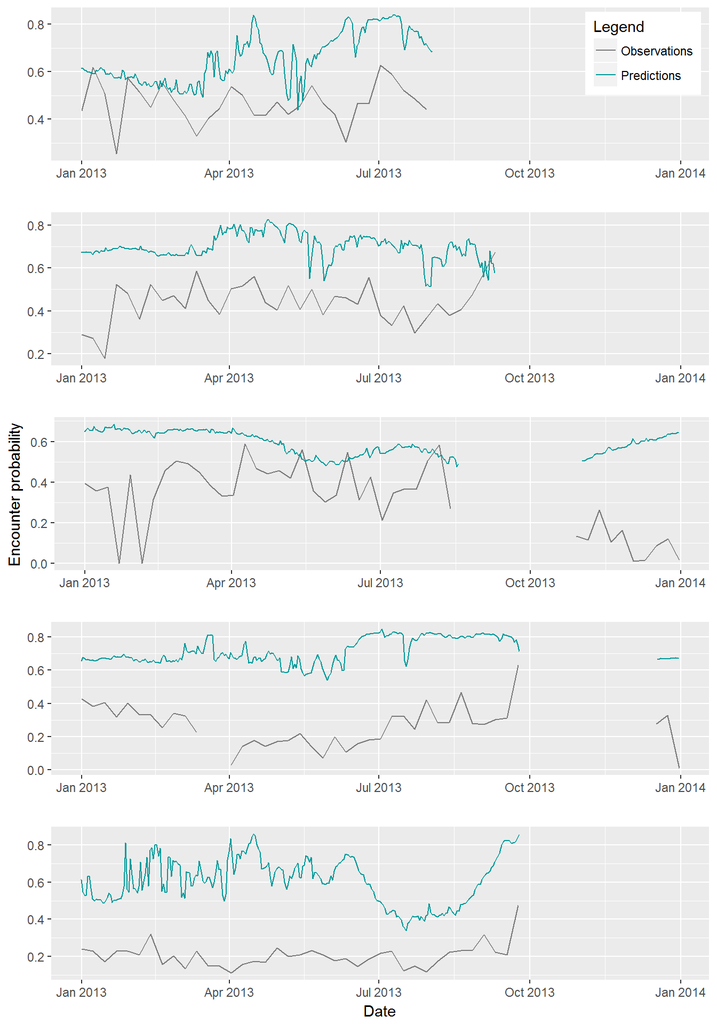

```r
# par(mfrow = c(5,1),oma=c(3,0,5,0)),colour="#000099",colour="#CC0000"
p1 <- ggplot() +
  geom_line(data = pOccur[occurIdx,],
             aes(x = as.POSIXct(dateStr), y = MC, color = Legend))+
  geom_line(data = Both_predictionSet,
            aes(x=date, y=MC, color = Legend)) +
  labs(y = "", x = "")+
  scale_color_manual(values= c("gray48","#009999"))+
  theme(legend.position = c(0.9, 0.7))

p2 <- ggplot() +
  geom_line(data = pOccur[occurIdx,],
             aes(x =as.POSIXct(dateStr), y = GC, color = Legend))+
  geom_line(data = Both_predictionSet,
            aes(x=date, y=GC, color = Legend)) +
  scale_color_manual(values= c("gray48","#009999"))+
  labs(y = "", x = "")+
  theme(legend.position="none")

p3 <- ggplot() +
  geom_line(data = pOccur[occurIdx,],
             aes(x =as.POSIXct(dateStr), y = DT, color = Legend))+
  geom_line(data = Both_predictionSet,
            aes(x=date, y=DT, color = Legend)) +
  scale_color_manual(values= c("gray48","#009999"))+
  labs(y = "Encounter probability", x = "")+
  theme(legend.position="none")

p4 <- ggplot() +
  geom_line(data = pOccur[occurIdx,],
             aes(x =as.POSIXct(dateStr), y = DC, color = Legend))+
  geom_line(data = Both_predictionSet,
            aes(x=date, y=DC, color = Legend)) +
  scale_color_manual(values= c("gray48","#009999"))+
  labs(y = "", x = "")+
  theme(legend.position="none")

p5 <- ggplot() +
  geom_line(data = pOccur[occurIdx,],
             aes(x =as.POSIXct(dateStr), y = MP, color = Legend))+
  geom_line(data = Both_predictionSet,
            aes(x=date, y=MP, color = Legend)) +
  scale_color_manual(values= c("gray48","#009999"))+
  labs(y = "", x = "Date")+
  theme(legend.position="none")

multiplot(p1, p2, p3, p4, p5, cols=1)
```

## Spatial Prediction

### Acoustic Only

Evaluate the models for summer (July 2009) and winter(January 2009) across the entire Gulf of Mexico (US EEZ beyond the 200m contour).

```r
dt1 <- as.data.frame(jan2009_rasters,xy=TRUE)

jan2009_AcOnly_prediction <- raster::predict(jan2009_rasters,
                                             AcOnly_gamm_pruned_TF_best$gam,
                                             type = 'response',na.action = na.pass)

july2009_AcOnly_prediction <- raster::predict(july2009_rasters,
                                              AcOnly_gamm_pruned_TF_best$gam,
                                              type = 'response',na.action = na.pass)
```

### Visual Only

```r
dt1 <- as.data.frame(jan2009_rasters,xy=TRUE)

jan2009_VisOnly_prediction <- raster::predict(jan2009_rasters,VisOnly_gamm_pruned_TF_best$gam,
            type = 'response',na.action = na.pass)

july2009_VisOnly_prediction <- raster::predict(july2009_rasters,VisOnly_gamm_pruned_TF_best$gam,
            type = 'response',na.action = na.pass)
```

### Joint Visual and Acoustic

```r
dt1 <- as.data.frame(jan2009_rasters,xy=TRUE)

jan2009_prediction <- raster::predict(jan2009_rasters,gamm_pruned_TF_best$gam,
            type = 'response',na.action = na.pass)

july2009_prediction <- raster::predict(july2009_rasters,gamm_pruned_TF_best$gam,
            type = 'response',na.action = na.pass)
```

Wrangle projections for mapping:

```r
predict_template <- readOGR('E:/NASData/AcoustoVisualDE/Prediction_template/prediction_polygon.shp')
map_proj <- sp::CRS('+proj=longlat +ellps=WGS84 +datum=WGS84 +no_defs')
predict_template_proj <- spTransform(predict_template, CRSobj = map_proj)

# Acoustic
jan2009_AcOnly_prediction_proj <- projectRaster(jan2009_AcOnly_prediction, crs=map_proj)
july2009_AcOnly_prediction_proj <- projectRaster(july2009_AcOnly_prediction, crs=map_proj)
jan2009_AcOnly_prediction_crop <- mask(jan2009_AcOnly_prediction_proj,predict_template_proj)
july2009_AcOnly_prediction_crop <-
  mask(july2009_AcOnly_prediction_proj,predict_template_proj)

# Visual
jan2009_VisOnly_prediction_proj <-
  projectRaster(jan2009_VisOnly_prediction, crs=map_proj)
july2009_VisOnly_prediction_proj <-
  projectRaster(july2009_VisOnly_prediction, crs=map_proj)
#jan2009_VisOnly_prediction_SE_proj <-
#  projectRaster(jan2009_VisOnly_prediction_SE, crs=map_proj)

jan2009_VisOnly_prediction_crop <-
  mask(jan2009_VisOnly_prediction_proj,predict_template_proj)
july2009_VisOnly_prediction_crop <- mask(july2009_VisOnly_prediction_proj,predict_template_proj)
#jan2009_VisOnly_prediction_SE_crop <- mask(jan2009_VisOnly_prediction_SE_proj,predict_template_proj)

#Both
jan2009_prediction_proj <- projectRaster(jan2009_prediction, crs=map_proj)
july2009_prediction_proj <- projectRaster(july2009_prediction, crs=map_proj)
jan2009_prediction_crop <- mask(jan2009_prediction_proj,predict_template_proj)
july2009_prediction_crop <- mask(july2009_prediction_proj,predict_template_proj)
```

### Model averaging

Alternatively, the visual and acoustic models could be averaged.

```r
jan2009mean <- mean(jan2009_AcOnly_prediction_crop,jan2009_VisOnly_prediction_crop)
july2009mean <- mean(july2009_AcOnly_prediction_crop,july2009_VisOnly_prediction_crop)
```

Display summer (July 2009) map:

```r
pal <- colorNumeric(palette = matlab.like2(5),
                    domain=c(0,1),
                    na.color = 'transparent')

map <- leaflet() %>%  setView(lng = -88.8, lat = 27.0, zoom = 6)%>%
  addProviderTiles(providers$Esri.OceanBasemap) %>%
  addRasterImage(july2009_AcOnly_prediction_crop, colors = pal,
                 opacity = 0.8, group = 'Acoustic July 2009') %>%
  addRasterImage(july2009_VisOnly_prediction_crop, colors = pal,
                 opacity = 0.8, group = 'Visual July 2009') %>%
  addRasterImage(july2009_prediction_crop, colors = pal,
                 opacity = 0.8, group = 'Joint July 2009') %>%
  addRasterImage(july2009mean,colors = pal,
                 opacity = 0.8, group = 'Vis. & Ac. Mean July 2009') %>%
addCircleMarkers(data = sightingsTest, lng = ~ long, lat = ~ lat,color = "black",
                 stroke = TRUE, fillOpacity = 0.8,radius = 6,
                 group = 'Test Sightings (Summer 2009)') %>%
  addLegend(pal = pal, values = c(0,1),
    title = 'P(encounter)',position = "bottomleft") %>%
  addLayersControl(
    baseGroups = c('Acoustic July 2009','Visual July 2009',
                   'Joint July 2009','Vis. & Ac. Mean July 2009'),
    overlayGroups = c('Test Sightings (Summer 2009)'),
    options = layersControlOptions(collapsed = FALSE)
  )
map
```

[interactive chart not shown]

Display winter (January 2009) map:

```r
pal <- colorNumeric(palette = matlab.like2(5),
                    domain=c(0,1),
                    na.color = 'transparent')

map <- leaflet() %>%  setView(lng = -88.8, lat = 27.0, zoom = 6)%>%
  addProviderTiles(providers$Esri.OceanBasemap) %>%
  addRasterImage(jan2009_AcOnly_prediction_crop, colors = pal,
                 opacity = 0.8, group = 'Acoustic Jan. 2009') %>%
  addRasterImage(jan2009_VisOnly_prediction_crop, colors = pal,
                 opacity = 0.8, group = 'Visual Jan. 2009') %>%
  addRasterImage(jan2009_prediction_crop, colors = pal,
                 opacity = 0.8, group = 'Joint Jan. 2009') %>%
  addRasterImage(jan2009mean,colors = pal,
                 opacity = 0.8, group = 'Vis. & Ac. Mean Jan. 2009') %>%
  addLegend(pal = pal, values = c(0,1),
    title = 'P(encounter)',position = "bottomleft") %>%
  addLayersControl(
    baseGroups = c('Acoustic Jan. 2009','Visual Jan. 2009',
                   'Joint Jan. 2009','Vis. & Ac. Mean Jan. 2009'),
    options = layersControlOptions(collapsed = FALSE)
  )
map
```

[interactive chart not shown]

# V. Monthly model predictions

Spatial model predictions using oceanographic variables averaged by month between 2003 and 2015.

```r
load('E:/NASData/AcoustoVisualDE/AcoustoVisualDE/climatology_rasters.Rdata')
monthNum <-c('01','02','03','04','05','06','07','08','09','10','11','12')
monthStr<-c('Jan','Feb','Mar','Apr','May','Jun','Jul','Aug','Sep','Oct','Nov','Dec')

climatePrediction <- vector('list',length = 12)
mapClimatePrediction <- vector('list',length = 12)

for (iM in 1:length(monthStr)){
  climatePrediction[[iM]] <- raster::predict(raster_set[[iM]],gamm_pruned_TF_best$gam,
            type = 'response',na.action = na.pass)
  mapClimatePrediction[[iM]] <- mask(projectRaster(climatePrediction[[iM]], crs=map_proj),predict_template_proj)
  # output raster to geotiff
  rasterImageFileName = paste0(savePath,'/climatology_predictions/', SP,'_',monthStr[iM],'_mean_encounter_probability.tif')
  writeRaster(mapClimatePrediction[[iM]],filename = rasterImageFileName, format="GTiff",overwrite = TRUE)

  #ouput raster to kml
  kmlImageFileName = paste0(savePath,'/climatology_predictions/', SP,'_',monthStr[iM],'_mean_encounter_probability.kml')
  KML(mapClimatePrediction[[iM]],file = kmlImageFileName, col=matlab.like2(32),overwrite = TRUE)


}
```

```r
pal <- colorNumeric(palette = matlab.like2(5),
                    domain=c(0,1),
                    na.color = 'transparent')

map <- leaflet() %>%  setView(lng = -88.8, lat = 27.0, zoom = 6)%>%
  addProviderTiles(providers$Esri.OceanBasemap) %>%
  addRasterImage(mapClimatePrediction[[1]] , colors = pal,
                 opacity = 0.8, group = 'Jan.') %>%
  addRasterImage(mapClimatePrediction[[4]] , colors = pal,
                 opacity = 0.8, group = 'April') %>%
  addRasterImage(mapClimatePrediction[[7]] , colors = pal,
                 opacity = 0.8, group = 'July') %>%
  addRasterImage(mapClimatePrediction[[10]] ,colors = pal,
                 opacity = 0.8, group = 'Oct.') %>%
  addLegend(pal = pal, values = c(0,1),
    title = 'P(encounter)',position = "bottomleft") %>%
  addLayersControl(
    baseGroups = c('Jan.','April',
                   'July','Oct.'),
    options = layersControlOptions(collapsed = FALSE)
  )
map
```

[interactive chart not shown]